# drillerの部屋

2017-10-01 python,numpy,matplotlib,finance

# 累積リターンをfor文を使わずに算出する冴えたやり方

[fin-pyもくもく会 #8](https://fin-py.connpass.com/event/66140/) で for文を使って累積リターンを算出して遅いという話をしていたら、[2casa](https://twitter.com/moscow_II) さんより、対数収益率を計算した後に合計したらよいのではないかとアドバイスいただきました。

確かに「Pythonでfor文を使ったら負け」という格言があることですし、色々試してみました。

# 前提条件

下記のように最初の株価を100円とし、1000日分の騰落率をランダムに与えてみます。

```python
import numpy as np


n = 1000  # データ数
s0 = 100  # 最初の株価
np.random.seed(10)
pct_change = np.random.randn(n - 1) * 0.01  # 騰落率

pct_change[:5]
```

```
array([  1.33158650e-02,   7.15278974e-03,  -1.54540029e-02,
        -8.38384993e-05,   6.21335974e-03])
```

上記の騰落率を使うと、2日目の株価は

100 + 100 * 1.33158650e-02 = 101.3315865

3日目の株価は

101.3315865 + 101.3315865 * 7.15278974e-03 = 102.05639003225512

となります。

# for文を使う

まずは古典的なfor文を使ってみます。

```python
%%time
stock_price1 = []
stock_price1.append(s0)

for x in pct_change:
    stock_price1.append(stock_price1[-1] * (1 + x))
```

```
CPU times: user 4 ms, sys: 0 ns, total: 4 ms
Wall time: 2.73 ms
```

前述した計算とあっているか確認してみましょう。

```python
stock_price1[:3]
```

```
[100, 101.33158650412952, 102.05639003681789]
```

あってそうですね。

リストの `append()` を使う処理は重いので、`numpy.ndarray` を使ってみます。

```python
%%time
stock_price2 = np.empty(n)
stock_price2[0] = s0

for i, x in enumerate(pct_change):
    stock_price2[i + 1] = stock_price2[i] * (1 + x)
```

```
CPU times: user 0 ns, sys: 0 ns, total: 0 ns
Wall time: 2.39 ms
```

速度に大きな改善はありませんでしたが、コードが少しスッキリしました。

# 累積積から算出する

`cumprod()` メソッドを使って累積積から算出します。  
for文を使わないのでさらにスッキリしました。処理速度も改善しています。

```python
%%time
stock_price3 = np.ones(1000)
stock_price3[1:] = (pct_change + 1).cumprod()
stock_price3 = stock_price3 * s0
```

```
CPU times: user 0 ns, sys: 0 ns, total: 0 ns
Wall time: 916 µs
```

# 対数収益率にした合計から算出する

対数収益率を使うと、累積リターンは合計(sum)から算出できます。  
なんと、1行で書くことができました！

```python
%%time
stock_price4 = np.exp(np.log(pct_change + 1).cumsum()) * s0
```

```
CPU times: user 0 ns, sys: 0 ns, total: 0 ns
Wall time: 1.01 ms
```

対数収益率にする利点としては、最後の収益を出したいだけなら合計するだけで算出できることです。

```python
%%time
np.exp(np.log(pct_change + 1).sum()) * s0
```

```
CPU times: user 0 ns, sys: 4 ms, total: 4 ms
Wall time: 795 µs
```

```
82.202144112704218
```

# 確認作業

それぞれの累積リターンの算出が合っているか確認してみます。

```python
print(stock_price1[-5:])
print(stock_price2[-5:])
print(stock_price3[-5:])
print(stock_price4[-5:])
```

```
[82.459395779138532, 81.622977823346162, 81.352130133710887, 82.524168158920119, 82.202144112704332]
[ 82.45939578  81.62297782  81.35213013  82.52416816  82.20214411]
[ 82.45939578  81.62297782  81.35213013  82.52416816  82.20214411]
[ 82.45939578  81.62297782  81.35213013  82.52416816  82.20214411]
```

[PythonユーザのためのJupyter[実践]入門](http://amzn.to/2fIhdjz) を参考に、算出した株価を可視化してみます。

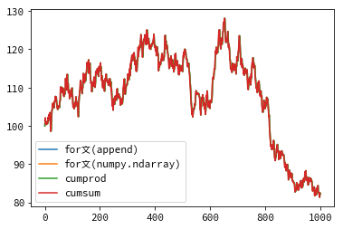

```python
import matplotlib.pyplot as plt
from matplotlib import rcParams


rcParams['font.sans-serif'] = 'Source Han Code JP'

plt.plot(stock_price1, label='for文(append)')
plt.plot(stock_price2, label='for文(numpy.ndarray)')
plt.plot(stock_price3, label='cumprod')
plt.plot(stock_price4, label='cumsum')
plt.legend()
plt.show()
```

4つの方法で算出した結果が全て重なっているので、問題なさそうですね。

Auther:  
driller  
Books:

[figure not shown]